# Assignment 4: Movie Review Analysis [50 Pt]

## Part 2. Model Building [2pt MODEL]

Build a recurrent neural network model, using an architecture of your choosing. Use one or more fully-connected layers to make the prediction based on your recurrent network output.

Instead of using the RNN output value for the final token, another often used strategy is to max-pool over the entire output array. That is, instead of calling something like:

```
out, _ = self.rnn(x)
self.fc(out[:, -1, :])
```

where `self.rnn` is an `nn.RNN`, `nn.GRU`, or `nn.LSTM` module, and `self.fc` is a fully-connected layer, we use:

```
out, _ = self.rnn(x)
self.fc(torch.max(out, dim=1)[0])
```

This works reasonably in practice. An even better alternative is to concatenate the max-pooling and average-pooling of the RNN outputs:

```
out, _ = self.rnn(x)
out = torch.cat([torch.max(out, dim=1)[0],
                 torch.mean(out, dim=1)], dim=1)
self.fc(out)
```

We encourage you to try out all these options. The way you pool the RNN outputs is one of the "hyperparameters" that you can choose to tune later on.

```python
# TO BE COMPLETED

class SentimentRNN(nn.Module):
    def __init__(self, vocab_size, embed_size, hidden_size, output_size, n_layers, drop_prob=0.5):
        super(SentimentRNN, self).__init__()

        # TO BE COMPLETED
        self.output_size = output_size
        self.n_layers = n_layers
        self.hidden_size = hidden_size

        # Embedding and LSTM layers
        self.embedding = nn.Embedding(vocab_size, embed_size)
        self.lstm = nn.LSTM(embed_size, hidden_size, n_layers,
                            dropout=drop_prob, batch_first=True)

        # Dropout layer
        self.dropout = nn.Dropout(drop_prob)

        # Pooling strategy: concatenate max-pooling and mean-pooling, so input dim is hidden_size * 2
        self.fc = nn.Linear(hidden_size * 2, output_size)
        self.sig = nn.Sigmoid()

    def forward(self, x, hidden):

        # TO BE COMPLETED
        batch_size = x.size(0)

        # Forward propagation
        embeds = self.embedding(x)
        lstm_out, hidden = self.lstm(embeds, hidden)

        # Using the better strategy from the assignment description: concatenate the max-pooling and average-pooling
        out = torch.cat([torch.max(lstm_out, dim=1)[0],
                         torch.mean(lstm_out, dim=1)], dim=1)

        out = self.dropout(out)
        out = self.fc(out)
        sig_out = self.sig(out)

        return sig_out, hidden

    def init_hidden(self, batch_size):
        # initialize LSTM hidden states
        weight = next(self.parameters()).data
        hidden = (weight.new(self.n_layers, batch_size, self.hidden_size).zero_().to(DEVICE),
                  weight.new(self.n_layers, batch_size, self.hidden_size).zero_().to(DEVICE))
        return hidden


# TO BE COMPLETED
vocab_size = 1000 + 1 # len(stoi) + 1 (1 for padding zero)
embed_size = 256
hidden_size = 128
output_size = 1
n_layers = 2

model = SentimentRNN(vocab_size, embed_size, hidden_size, output_size, n_layers)
model.to(DEVICE)
print(model)
```

```
SentimentRNN(
  (embedding): Embedding(1001, 256)
  (lstm): LSTM(256, 128, num_layers=2, batch_first=True, dropout=0.5)
  (dropout): Dropout(p=0.5, inplace=False)
  (fc): Linear(in_features=256, out_features=1, bias=True)
  (sig): Sigmoid()
)
```

## Part 3. Training [3 pt]

### Part (i) [1pt MODEL]

Complete the `get_accuracy` function, which will compute the accuracy (rate) of your model across a dataset (e.g. validation set).

```python
def get_accuracy(model, data):
    """ Compute the accuracy of the `model` across a dataset `data`

    Example usage:

    >>> model = MyRNN() # to be defined
    >>> get_accuracy(model, valid_loader) # the variable `valid_loader` is from above
    """

    # TO BE COMPLETED
    correct, total = 0, 0
    model.eval() # Set model to evaluation mode

    with torch.no_grad():
        for reviews, labels in data:
            # Move data to the correct device
            reviews, labels = reviews.to(DEVICE), labels.to(DEVICE)

            # Initialize hidden state for the current batch
            hidden = model.init_hidden(reviews.size(0))

            # Forward pass
            output, hidden = model(reviews, hidden)

            # Convert probabilities to binary predictions (0 or 1)
            pred = torch.round(output.squeeze())

            # Calculate correct predictions
            correct += pred.eq(labels.view_as(pred)).sum().item()
            total += labels.shape[0]

    model.train() # Set model back to training mode
    return correct / total
```

### Part (ii) [1pt MODEL]

Train your model. Plot the training curve of your final model. Your training curve should have the training/validation loss and accuracy plotted periodically.

It is recommended to save the best model checkpoint based on validation accuracy so that you can reload it later if your notebook runtime restarts.

```python
def train_model(model, train_loader, val_loader, learning_rate=0.005, num_epochs=5,
                checkpoint_name="lstm_best.pt", show_plot=True):
    """
    Train the model and optionally plot the training curves.
    Returns the best validation accuracy achieved.
    """
    criterion = nn.BCELoss()
    optimizer = optim.Adam(model.parameters(), lr=learning_rate)

    best_val_acc = 0.0
    train_losses, val_losses = [], []
    train_accs, val_accs = [], []

    print("Starting training")
    for epoch in range(num_epochs):
        # Training phase
        model.train()
        total_train_loss = 0.0
        correct_train = 0
        total_train = 0

        for reviews, labels in train_loader:
            reviews = reviews.to(DEVICE)
            labels = labels.to(DEVICE).float()

            hidden = model.init_hidden(reviews.size(0))

            optimizer.zero_grad()
            output, hidden = model(reviews, hidden)

            loss = criterion(output.squeeze(1), labels)
            loss.backward()

            nn.utils.clip_grad_norm_(model.parameters(), max_norm=5)
            optimizer.step()

            total_train_loss += loss.item() * reviews.size(0)

            pred = torch.round(output.squeeze(1))
            correct_train += pred.eq(labels).sum().item()
            total_train += labels.size(0)

        train_loss = total_train_loss / total_train
        train_acc = correct_train / total_train

        # Validation phase
        model.eval()
        total_val_loss = 0.0
        correct_val = 0
        total_val = 0

        with torch.no_grad():
            for reviews, labels in val_loader:
                reviews = reviews.to(DEVICE)
                labels = labels.to(DEVICE).float()

                hidden = model.init_hidden(reviews.size(0))
                output, hidden = model(reviews, hidden)

                loss = criterion(output.squeeze(1), labels)
                total_val_loss += loss.item() * reviews.size(0)

                pred = torch.round(output.squeeze(1))
                correct_val += pred.eq(labels).sum().item()
                total_val += labels.size(0)

        val_loss = total_val_loss / total_val
        val_acc = correct_val / total_val

        train_losses.append(train_loss)
        val_losses.append(val_loss)
        train_accs.append(train_acc)
        val_accs.append(val_acc)

        print(f"Epoch {epoch+1}/{num_epochs} | "
              f"Train Loss: {train_loss:.4f} | Train Acc: {train_acc:.4f} | "
              f"Val Loss: {val_loss:.4f} | Val Acc: {val_acc:.4f}")

        save_checkpoint(
            os.path.join(CHECKPOINT_DIR, "lstm_last.pt"),
            model,
            optimizer=optimizer,
            epoch=epoch,
            best_val_acc=best_val_acc
        )

        if val_acc > best_val_acc:
            best_val_acc = val_acc
            save_checkpoint(
                os.path.join(CHECKPOINT_DIR, checkpoint_name),
                model,
                optimizer=optimizer,
                epoch=epoch,
                best_val_acc=best_val_acc
            )
            print(f"Saved best LSTM checkpoint at epoch {epoch+1} with acc: {best_val_acc:.4f}")

    if show_plot:
        plt.figure(figsize=(12, 5))

        plt.subplot(1, 2, 1)
        plt.plot(range(1, num_epochs + 1), train_losses, label='Train Loss')
        plt.plot(range(1, num_epochs + 1), val_losses, label='Val Loss')
        plt.title('Training and Validation Loss')
        plt.xlabel('Epochs')
        plt.ylabel('Loss')
        plt.legend()

        plt.subplot(1, 2, 2)
        plt.plot(range(1, num_epochs + 1), train_accs, label='Train Accuracy')
        plt.plot(range(1, num_epochs + 1), val_accs, label='Val Accuracy')
        plt.title('Training and Validation Accuracy')
        plt.xlabel('Epochs')
        plt.ylabel('Accuracy')
        plt.legend()

        plt.tight_layout()
        plt.show()

    return best_val_acc
```

```
Starting training
Saved best LSTM checkpoint at epoch 1 with acc: 0.8386
```

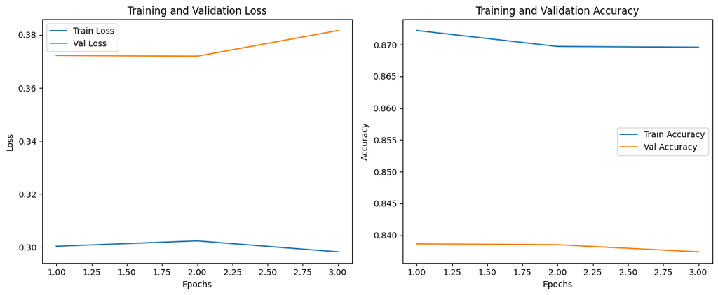

```
Training finished | Best Validation Accuracy: 0.8386
```

```python
#training
best_acc = train_model(model, train_loader, val_loader, learning_rate=0.005, num_epochs=3)

print(f"\nTraining finished | Best Validation Accuracy: {best_acc:.4f}")
```

### Part (iii) [1pt MODEL]

Choose at least 4 hyperparameters to tune. Explain how you tuned the hyperparameters. You don't need to include your training curve for every model you trained. Instead, explain what hyperparemters you tuned, what the best validation accuracy was, and the reasoning behind the hyperparameter decisions you made.

For this assignment, you should tune more than just your learning rate and epoch. Choose at least 2 hyperparameters that are unrelated to the optimizer.

```
Starting training
Saved best LSTM checkpoint at epoch 1 with acc: 0.8317
Saved best LSTM checkpoint at epoch 3 with acc: 0.8405
```

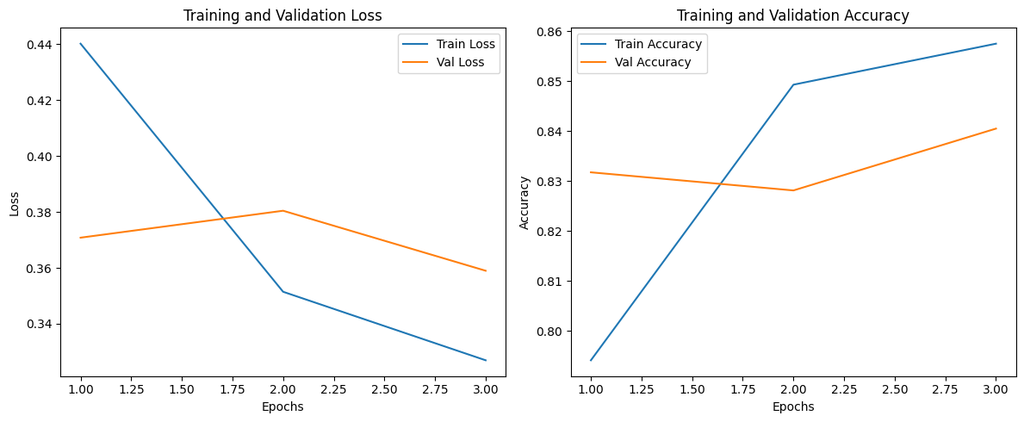

```python
# TO BE COMPLETED


#basedline model

model = SentimentRNN(
    vocab_size=vocab_size,
    embed_size=256,
    hidden_size=128,
    output_size=1,
    n_layers=2,
    drop_prob=0.5
).to(DEVICE)



best_acc = train_model(model, train_loader, val_loader,
                       learning_rate=0.005,
                       num_epochs=3,
                       checkpoint_name="baseline.pt",
                       show_plot=True)
```

```
Starting training
Saved best LSTM checkpoint at epoch 1 with acc: 0.8176
Saved best LSTM checkpoint at epoch 2 with acc: 0.8391
```

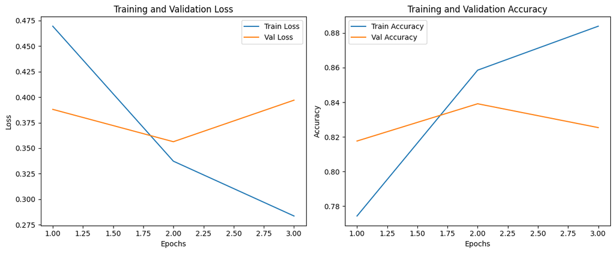

```python
#model2
model = SentimentRNN(vocab_size, 256, 128, 1, 2, drop_prob=0.5).to(DEVICE)
acc2 = train_model(model, train_loader, val_loader,
                   learning_rate=0.001,
                   num_epochs=3,
                   checkpoint_name="lr001.pt",
                   show_plot=True)
```

```
Starting training
Saved best LSTM checkpoint at epoch 1 with acc: 0.8195
Saved best LSTM checkpoint at epoch 2 with acc: 0.8387
Saved best LSTM checkpoint at epoch 3 with acc: 0.8400
```

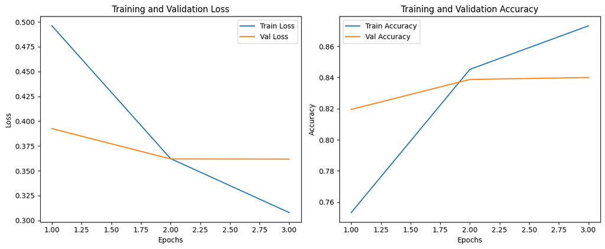

```python
#model3
model = SentimentRNN(vocab_size, 256, 128, 1, 2, drop_prob=0.7).to(DEVICE)
acc2 = train_model(model, train_loader, val_loader,
                   learning_rate=0.001,
                   num_epochs=3,
                   checkpoint_name="droprate07.pt",
                   show_plot=True)
```

```
Starting training
Saved best LSTM checkpoint at epoch 1 with acc: 0.8254
Saved best LSTM checkpoint at epoch 2 with acc: 0.8434
```

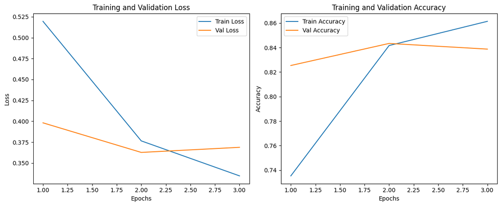

```python
#model4
model = SentimentRNN(vocab_size, 256, 64, 1, 2, drop_prob=0.7).to(DEVICE)
acc_hidden64 = train_model(model, train_loader, val_loader,
                           learning_rate=0.001,
                           num_epochs=3,
                           checkpoint_name="hidden64.pt",
                           show_plot=True)
```